# Annotation_Enrichment_Functional

Galindo, B. A

2024-05-01

# VARIANT EFFECT PREDICTOR (VEP) https://www.ensembl.org/Homo_sapiens/Tools/VEP

After perform the GWAS analysis we got as output a list of **significan SNPs** that are associated with our trait.

The very first step to understand what this SNPs could represent can be a VEP analysis. With this analysis get more information about the location of our variants (SNPs generated by mutations) and therefor infer some consequences of them. We are gonna check if our variant falls into:

- intergenic region
- Intron (non coding)
- exon (coding)
- lncRNA

But, first we need to proivde the rsID of our variants.

## Getting the rsID

The rsID is a “stable” ID that doesn’t change along the time. So is a better use than “comercial” SNP Name. We are gonna get this IDs using the website **SNPchimp** https://webserver.ibba.cnr.it/SNPchimp/index.php/links

Using the tab BROWSE hit the link for your specie.

[figure not shown]

Now, paste your SNPnames in the search area separated by comma.

[figure not shown]

Now you have your rsID and you can download this output in CSV or TSV format.

[figure not shown]

## Running VEP

You can find the VEP in the website https://www.ensembl.org/Homo_sapiens/Tools/VEP

[figure not shown]

# GALLO

To perform gene annotation we are gonna use the package GALLO

To use GALLO you need three different imput file:

- GWAS output
- QTL position
- GENE postion

## QTL position

  Acess the website https://www.animalgenome.org/cgi-bin/QTLdb/index and hit the link for your specie

[figure not shown]

[figure not shown]

## GENE position

  Acess the **Ensemble FTP download** page https://www.ensembl.org/info/data/ftp/index.html?redirect=no to download the **.gtf** file

  Use the seach area to find your specie, and than download the GTF file.

[figure not shown]

  It is also important double check the reference genome from which you are downloading the gene position. This must be the same genome reference version that the *.map* file you have used. To do this, hit the specie name,

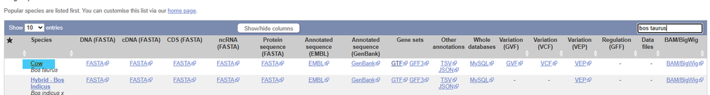

  than check on the left top corner the Reference Genome version. If you need to change, use the drop down menu, and be sure to hit the **GO** buton.

[figure not shown]

  Now check again in the top left corner the genome reference version, and click on Download GTF

[figure not shown]

  And download the gtf file.

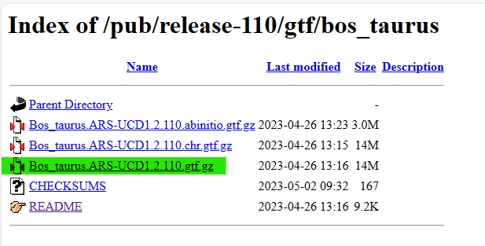

  Now you have the two files with gene and QTL position for your reference genome.

## Significant Markers

  The last file that you need is the output of your GWAS analysis, the file with the Chromosome, SNP name and SNP position for your significant SNPs.

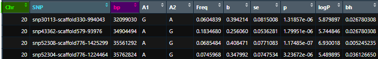

## find_genes_qtls_around_markers function

  Now you are gonna need to load the three imput files as in the code below.

  Than you are gonna run the function **find_genes_qtls_around_markers** setting up the correct method choosing **GENE** or **QTL**.

  You also need to choose the proper **interval** that is the range that GALLO will check upstream and downstream of you SNP position.

  ```r
  #import a QTL annotation file
  qtl_dbb <- import_gff_gtf(db_file="/Animal_QTLdb_release52_goatCHIR_ARS1.gff.gz",file_type="gff")

  #import a gene annotation file
  gene_dbb <- import_gff_gtf(db_file="/Capra_hircus.ARS1.111.gtf.gz",file_type="gtf")

  #import MARKER files = the GWAS output
  gwas <- read.table(file = "/SNP_sig_BH.txt",
                     head=T, stringsAsFactors = F)

  # Assuming "gwas" is your dataframe
  gwas <- subset(gwas, select = c(Chr, SNP, bp))


  colnames(gwas) <- c("CHR","SNP", "BP")


  #FINDING GENES AND QTLs ARROUND THE MARKER

  #FINDING GENES
  out.genes <- find_genes_qtls_around_markers(db_file= gene_dbb,
                                              marker_file= gwas,
                                              method = "gene",
                                              marker = "snp",
                                              interval = 50000,
                                              nThreads = NULL)

  write.table(out.genes, file = "/out_genes_50k.txt",
              quote = FALSE, sep = "\t", row.names = FALSE, col.names = T)

  #FINDING QTLs

  out.qtl <- find_genes_qtls_around_markers(db_file= qtl_dbb,
                                            marker_file= gwas,
                                            method = "qtl",
                                            marker = "snp",
                                            interval = 50000,
                                            nThreads = NULL)

  write.table(out.qtl, file = "/out_qtl_50k.txt",
              quote = FALSE, sep = "\t", row.names = FALSE, col.names = T)
  ```

  Now, as output you have two files with the Genes and QTL surrounding your SNP into your interval.

  **GENE**

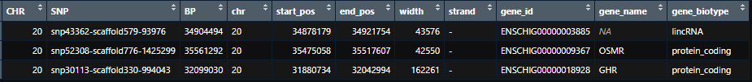

  **QTL**

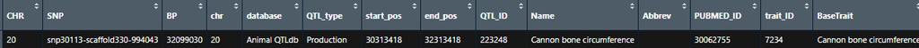

## QTL summary

### Pie chart

  With this function you are gonna plot the percentage of each QTL class annoatted

### Bar chart

  plotting the percentage of each trait annoatted for a determined class of QTL, for instance *Reproduction QTL*

# Enrichment analysis

Now we have our genes and QTLs surrounding our significant SNPs. We can check for the presence of this genes in specific terms, and test the significance of this “presence”.

**ps.** from now every time I use the word **term** could be a GO term (GO: Molecular Function, GO: Cellular Component, GO: Biological Process), KEGG Pathway, REACTOME Pathway and other terms.